# Divvy Case Study

Rungchat Amnuay

2023-03-31

## **Senario**

I am a junior data analyst working in the marketing analyst team at Cyclistic, a bike-share company in Chicago. The director of marketing believes the company’s future success depends on maximizing the number of annual memberships. Therefore, my team wants to understand how casual riders and annual members use Cyclistic bikes differently. From these insights, my team will design a new marketing strategy to convert casual riders into annual members. But first, Cyclistic executives must approve my recommendations, so they must be backed up with compelling data insights and professional data visualizations.

I was assigned to analyze the descriptive insight from the Divvy customer and comparing between casual member and annual member. The business question is “How to convert a casual member to become a annual member.

## **Preparing the data**

### Step 1: Getting data

I use the public data set from https://divvy-tripdata.s3.amazonaws.com/index.html with 4 data sets to analyze including

- Divvy_Trips_2019_Q2.csv
- Divvy_Trips_2019_Q3.csv
- Divvy_Trips_2019_Q4.csv
- Divvy_Trips_2020_Q1.csv

All of these files were collected by Divvy itself. Therefore It is Reliable, Original, and Comprehensive

### Step 2: Install packages

- install.packages(“tidyverse”)
- install.packages(“dplyr”)
- install.packages(“patchwork”)

### Step 3: Loading library

```r
library(tidyverse)
library(dplyr)
library(lubridate)
library(hms)
library(ggplot2)
library(patchwork)
library(forcats)
library(scales)
```

### Step 4: Import data

I decided to use RStudio desktop version for a data manipulation tool. The reasons are

1. Each file contain a numerous records
2. RStudio desktop version works on local memory. Then it can work faster than RStudio cloud.

```r
q2_2019 <- read_csv("Divvy_Trips_2019_Q2.csv")
q3_2019 <- read_csv("Divvy_Trips_2019_Q3.csv")
q4_2019 <- read_csv("Divvy_Trips_2019_Q4.csv")
q1_2020 <- read_csv("Divvy_Trips_2020_Q1.csv")
```

### Step 5: Preview data

Preview the consistency of all files column name and planing for manipulate them before integrate them.

```r
colnames(q3_2019)
```

```
##  [1] "trip_id"           "start_time"        "end_time"
##  [4] "bikeid"            "tripduration"      "from_station_id"
##  [7] "from_station_name" "to_station_id"     "to_station_name"
## [10] "usertype"          "gender"            "birthyear"
```

```r
colnames(q4_2019)
```

```
##  [1] "trip_id"           "start_time"        "end_time"
##  [4] "bikeid"            "tripduration"      "from_station_id"
##  [7] "from_station_name" "to_station_id"     "to_station_name"
## [10] "usertype"          "gender"            "birthyear"
```

```r
colnames(q2_2019)
```

```
##  [1] "01 - Rental Details Rental ID"
##  [2] "01 - Rental Details Local Start Time"
##  [3] "01 - Rental Details Local End Time"
##  [4] "01 - Rental Details Bike ID"
##  [5] "01 - Rental Details Duration In Seconds Uncapped"
##  [6] "03 - Rental Start Station ID"
##  [7] "03 - Rental Start Station Name"
##  [8] "02 - Rental End Station ID"
##  [9] "02 - Rental End Station Name"
## [10] "User Type"
## [11] "Member Gender"
## [12] "05 - Member Details Member Birthday Year"
```

```r
colnames(q1_2020)
```

```
##  [1] "ride_id"            "rideable_type"      "started_at"
##  [4] "ended_at"           "start_station_name" "start_station_id"
##  [7] "end_station_name"   "end_station_id"     "start_lat"
## [10] "start_lng"          "end_lat"            "end_lng"
## [13] "member_casual"
```

### Step 6: Manipulate data and merge to a single file.

#### **6.1 Renaming column name to be consistence.**

```r
(q4_2019 <- rename(q4_2019,
                   ride_id = trip_id,
                   rideable_type = bikeid,
                   started_at = start_time,
                   ended_at = end_time,
                   start_station_name = from_station_name,
                   start_station_id = from_station_id,
                   end_station_name = to_station_name,
                   end_station_id = to_station_id,
                   member_casual = usertype))
```

```
## # A tibble: 704,054 × 12
##     ride_id started_at          ended_at            rideable_t…¹ tripd…² start…³
##       <dbl> <dttm>              <dttm>                     <dbl>   <dbl>   <dbl>
##  1 25223640 2019-10-01 00:01:39 2019-10-01 00:17:20         2215     940      20
##  2 25223641 2019-10-01 00:02:16 2019-10-01 00:06:34         6328     258      19
##  3 25223642 2019-10-01 00:04:32 2019-10-01 00:18:43         3003     850      84
##  4 25223643 2019-10-01 00:04:32 2019-10-01 00:43:43         3275    2350     313
##  5 25223644 2019-10-01 00:04:34 2019-10-01 00:35:42         5294    1867     210
##  6 25223645 2019-10-01 00:04:38 2019-10-01 00:10:51         1891     373     156
##  7 25223646 2019-10-01 00:04:52 2019-10-01 00:22:45         1061    1072      84
##  8 25223647 2019-10-01 00:04:57 2019-10-01 00:29:16         1274    1458     156
##  9 25223648 2019-10-01 00:05:20 2019-10-01 00:29:18         6011    1437     156
## 10 25223649 2019-10-01 00:05:20 2019-10-01 02:23:46         2957    8306     336
## # … with 704,044 more rows, 6 more variables: start_station_name <chr>,
## #   end_station_id <dbl>, end_station_name <chr>, member_casual <chr>,
## #   gender <chr>, birthyear <dbl>, and abbreviated variable names
## #   ¹rideable_type, ²tripduration, ³start_station_id
```

```r
(q3_2019 <- rename(q3_2019,
                   ride_id = trip_id,
                   rideable_type = bikeid,
                   started_at = start_time,
                   ended_at = end_time,
                   start_station_name = from_station_name,
                   start_station_id = from_station_id,
                   end_station_name = to_station_name,
                   end_station_id = to_station_id,
                   member_casual = usertype))
```

```
## # A tibble: 1,640,718 × 12
##     ride_id started_at          ended_at            rideable_t…¹ tripd…² start…³
##       <dbl> <dttm>              <dttm>                     <dbl>   <dbl>   <dbl>
##  1 23479388 2019-07-01 00:00:27 2019-07-01 00:20:41         3591    1214     117
##  2 23479389 2019-07-01 00:01:16 2019-07-01 00:18:44         5353    1048     381
##  3 23479390 2019-07-01 00:01:48 2019-07-01 00:27:42         6180    1554     313
##  4 23479391 2019-07-01 00:02:07 2019-07-01 00:27:10         5540    1503     313
##  5 23479392 2019-07-01 00:02:13 2019-07-01 00:22:26         6014    1213     168
##  6 23479393 2019-07-01 00:02:21 2019-07-01 00:07:31         4941     310     300
##  7 23479394 2019-07-01 00:02:24 2019-07-01 00:23:12         3770    1248     168
##  8 23479395 2019-07-01 00:02:26 2019-07-01 00:28:16         5442    1550     313
##  9 23479396 2019-07-01 00:02:34 2019-07-01 00:28:57         2957    1583      43
## 10 23479397 2019-07-01 00:02:45 2019-07-01 00:29:14         6091    1589      43
## # … with 1,640,708 more rows, 6 more variables: start_station_name <chr>,
## #   end_station_id <dbl>, end_station_name <chr>, member_casual <chr>,
## #   gender <chr>, birthyear <dbl>, and abbreviated variable names
## #   ¹rideable_type, ²tripduration, ³start_station_id
```

```r
(q2_2019 <- rename(q2_2019,
                   ride_id = "01 - Rental Details Rental ID",
                   rideable_type = "01 - Rental Details Bike ID",
                   started_at = "01 - Rental Details Local Start Time",
                   ended_at = "01 - Rental Details Local End Time",
                   start_station_name = "03 - Rental Start Station Name",
                   start_station_id = "03 - Rental Start Station ID",
                   end_station_name = "02 - Rental End Station Name",
                   end_station_id = "02 - Rental End Station ID",
                   member_casual = "User Type"))
```

```
## # A tibble: 1,108,163 × 12
##     ride_id started_at          ended_at            rideable_t…¹ 01 - …² start…³
##       <dbl> <dttm>              <dttm>                     <dbl>   <dbl>   <dbl>
##  1 22178529 2019-04-01 00:02:22 2019-04-01 00:09:48         6251     446      81
##  2 22178530 2019-04-01 00:03:02 2019-04-01 00:20:30         6226    1048     317
##  3 22178531 2019-04-01 00:11:07 2019-04-01 00:15:19         5649     252     283
##  4 22178532 2019-04-01 00:13:01 2019-04-01 00:18:58         4151     357      26
##  5 22178533 2019-04-01 00:19:26 2019-04-01 00:36:13         3270    1007     202
##  6 22178534 2019-04-01 00:19:39 2019-04-01 00:23:56         3123     257     420
##  7 22178535 2019-04-01 00:26:33 2019-04-01 00:35:41         6418     548     503
##  8 22178536 2019-04-01 00:29:48 2019-04-01 00:36:11         4513     383     260
##  9 22178537 2019-04-01 00:32:07 2019-04-01 01:07:44         3280    2137     211
## 10 22178538 2019-04-01 00:32:19 2019-04-01 01:07:39         5534    2120     211
## # … with 1,108,153 more rows, 6 more variables: start_station_name <chr>,
## #   end_station_id <dbl>, end_station_name <chr>, member_casual <chr>,
## #   `Member Gender` <chr>, `05 - Member Details Member Birthday Year` <dbl>,
## #   and abbreviated variable names ¹rideable_type,
## #   ²`01 - Rental Details Duration In Seconds Uncapped`, ³start_station_id
```

#### **6.2 Covert ride_id and rideable_type to character to stack correctly.**

```r
q4_2019 <-  mutate(q4_2019, ride_id = as.character(ride_id),
                   rideable_type = as.character(rideable_type))
q3_2019 <-  mutate(q3_2019, ride_id = as.character(ride_id),
                   rideable_type = as.character(rideable_type))
q2_2019 <-  mutate(q2_2019, ride_id = as.character(ride_id),
                   rideable_type = as.character(rideable_type))
```

#### **6.3 Merging from 4 files to a single file and drop unrelated columns out of dataframe.**

```r
all_trips <- bind_rows(q2_2019, q3_2019, q4_2019, q1_2020)

all_trips <- all_trips %>%
  select(-c(start_lat,
            start_lng,
            end_lat,
            end_lng,
            birthyear,
            gender,
            "01 - Rental Details Duration In Seconds Uncapped",
            "05 - Member Details Member Birthday Year",
            "Member Gender", "tripduration"))
tibble(all_trips)
```

```
## # A tibble: 3,879,822 × 9
##    ride_id  started_at          ended_at            rideable_t…¹ start…² start…³
##    <chr>    <dttm>              <dttm>              <chr>          <dbl> <chr>
##  1 22178529 2019-04-01 00:02:22 2019-04-01 00:09:48 6251              81 Daley …
##  2 22178530 2019-04-01 00:03:02 2019-04-01 00:20:30 6226             317 Wood S…
##  3 22178531 2019-04-01 00:11:07 2019-04-01 00:15:19 5649             283 LaSall…
##  4 22178532 2019-04-01 00:13:01 2019-04-01 00:18:58 4151              26 McClur…
##  5 22178533 2019-04-01 00:19:26 2019-04-01 00:36:13 3270             202 Halste…
##  6 22178534 2019-04-01 00:19:39 2019-04-01 00:23:56 3123             420 Ellis …
##  7 22178535 2019-04-01 00:26:33 2019-04-01 00:35:41 6418             503 Drake …
##  8 22178536 2019-04-01 00:29:48 2019-04-01 00:36:11 4513             260 Kedzie…
##  9 22178537 2019-04-01 00:32:07 2019-04-01 01:07:44 3280             211 St. Cl…
## 10 22178538 2019-04-01 00:32:19 2019-04-01 01:07:39 5534             211 St. Cl…
## # … with 3,879,812 more rows, 3 more variables: end_station_id <dbl>,
## #   end_station_name <chr>, member_casual <chr>, and abbreviated variable names
## #   ¹rideable_type, ²start_station_id, ³start_station_name
```

### Step 7: Start working with a single dataframe.

#### **7.1 Reinspect the dataframe.**

I started focus on member type based on main objective of analysis. I inspected that column by

```r
table(all_trips$member_casual)
```

```
##
##     casual   Customer     member Subscriber
##      48480     857474     378407    2595461
```

In the member_casual columns, there are something not consistence.

- there are 2 names for annual member: “member” and “Subscriber”
- there are 2 names for casual rider: “Customer” and “casual”

I fixed by

```r
all_trips <-  all_trips %>%
  mutate(member_casual = recode(member_casual,
                                "Subscriber" = "member",
                                "Customer" = "casual"))
```

Double-check the result.

```r
table(all_trips$member_casual)
```

```
##
##  casual  member
##  905954 2973868
```

#### **7.2 Manipulate and create aggregate ride data.**

##### Create Day, Month, Year and Day of Week coloumns for further analysis.

Because in the started_at and ended_at columns contain the YYYY-MM-DD with “POSIXct” and “POSIXt” classes.

```r
all_trips$date <- as.Date(all_trips$started_at) #The default format is yyyy-mm-dd
all_trips$month <- format(as.Date(all_trips$date), "%m")
all_trips$day <- format(as.Date(all_trips$date), "%d")
all_trips$year <- format(as.Date(all_trips$date), "%Y")
all_trips$day_of_week <- format(as.Date(all_trips$date), "%A")
```

##### Calculate the ride length in a new columns.

```r
all_trips$ride_length <- difftime(all_trips$ended_at,all_trips$started_at)

all_trips$ride_length <- as.numeric(all_trips$ride_length)
```

##### Drop BAD data from data frame and create the final version of dataframe.

In the dataframe include unintentional errors. I decided to ask the project manager for advice and they recommended to drop all of the errors.

```r
all_trips_v2 <- all_trips[!(all_trips$start_station_name == "HQ QR" | all_trips$ride_length<0),]
```

#### Convert Month/Year to Quarter

```r
all_trips_v2 <- mutate(all_trips_v2, quarter = quarter(all_trips_v2$started_at)) |>
                  mutate(Q = case_when(
                    quarter == 1 ~ "Q1_2020",
                    quarter == 2 ~ "Q2_2019",
                    quarter == 3 ~ "Q3_2019",
                    quarter == 4 ~ "Q4_2019",
                    TRUE ~ "Unidentified"
                  )) |>
                  mutate(Q = as.factor(Q))
```

## **Analyze the data**

### Descriptive statistics

```r
all_trips_v2 |>
  summarise(total_mean = mean(all_trips_v2$ride_length),
            total_median = median(all_trips_v2$ride_length),
            total_min = min(all_trips_v2$ride_length),
            total_max = max(all_trips_v2$ride_length))
```

```
## # A tibble: 1 × 4
##   total_mean total_median total_min total_max
##        <dbl>        <dbl>     <dbl>     <dbl>
## 1      1479.          712         1   9387024
```

```r
aggregate(all_trips_v2$ride_length ~ all_trips_v2$member_casual, FUN = mean)
```

```
##   all_trips_v2$member_casual all_trips_v2$ride_length
## 1                     casual                3552.7502
## 2                     member                 850.0662
```

```r
aggregate(all_trips_v2$ride_length ~ all_trips_v2$member_casual, FUN = median)
```

```
##   all_trips_v2$member_casual all_trips_v2$ride_length
## 1                     casual                     1546
## 2                     member                      589
```

```r
aggregate(all_trips_v2$ride_length ~ all_trips_v2$member_casual, FUN = max)
```

```
##   all_trips_v2$member_casual all_trips_v2$ride_length
## 1                     casual                  9387024
## 2                     member                  9056634
```

```r
aggregate(all_trips_v2$ride_length ~ all_trips_v2$member_casual, FUN = min)
```

```
##   all_trips_v2$member_casual all_trips_v2$ride_length
## 1                     casual                        2
## 2                     member                        1
```

### Member Type Proportion.

```r
all_trips_v2|>
  group_by(member_casual) |>
  summarise(member_type_n = n())
```

```
## # A tibble: 2 × 2
##   member_casual member_type_n
##   <chr>                 <int>
## 1 casual               902182
## 2 member              2973860
```

### The average ride length between annual member(member) and casual ride(casual) by day of week.

```r
aggregate(all_trips_v2$ride_length ~ all_trips_v2$member_casual +
            all_trips_v2$day_of_week, FUN = mean)
```

```
##    all_trips_v2$member_casual all_trips_v2$day_of_week all_trips_v2$ride_length
## 1                      casual                   Friday                3773.8351
## 2                      member                   Friday                 824.5305
## 3                      casual                   Monday                3372.2869
## 4                      member                   Monday                 842.5726
## 5                      casual                 Saturday                3331.9138
## 6                      member                 Saturday                 968.9337
## 7                      casual                   Sunday                3581.4054
## 8                      member                   Sunday                 919.9746
## 9                      casual                 Thursday                3682.9847
## 10                     member                 Thursday                 823.9278
## 11                     casual                  Tuesday                3596.3599
## 12                     member                  Tuesday                 826.1427
## 13                     casual                Wednesday                3718.6619
## 14                     member                Wednesday                 823.9996
```

```r
##reorder day of week
all_trips_v2$day_of_week <- ordered(all_trips_v2$day_of_week,
                                    levels=c("Sunday", "Monday", "Tuesday", "Wednesday", "Thursday", "Friday", "Saturday"))

aggregate(all_trips_v2$ride_length ~ all_trips_v2$member_casual +
            all_trips_v2$day_of_week, FUN = mean)
```

```
##    all_trips_v2$member_casual all_trips_v2$day_of_week all_trips_v2$ride_length
## 1                      casual                   Sunday                3581.4054
## 2                      member                   Sunday                 919.9746
## 3                      casual                   Monday                3372.2869
## 4                      member                   Monday                 842.5726
## 5                      casual                  Tuesday                3596.3599
## 6                      member                  Tuesday                 826.1427
## 7                      casual                Wednesday                3718.6619
## 8                      member                Wednesday                 823.9996
## 9                      casual                 Thursday                3682.9847
## 10                     member                 Thursday                 823.9278
## 11                     casual                   Friday                3773.8351
## 12                     member                   Friday                 824.5305
## 13                     casual                 Saturday                3331.9138
## 14                     member                 Saturday                 968.9337
```

### Ride Distribution by Number of Rides and Average Duration Grouped by Member Types and Day of Week

```r
all_trips_v2 %>%
  mutate(weekday = wday(started_at, label = TRUE)) %>%  #creates weekday field using wday()
  group_by(member_casual, weekday) %>%  #groups by user type and weekday
  summarise(number_of_rides = n()       #calculates the number of rides and average duration
            ,average_duration = mean(ride_length)) %>%  # calculates the average duration
  arrange(member_casual, weekday)   # sorts
```

```
## # A tibble: 14 × 4
## # Groups:   member_casual [2]
##    member_casual weekday number_of_rides average_duration
##    <chr>         <ord>             <int>            <dbl>
##  1 casual        Sun              181293            3581.
##  2 casual        Mon              103296            3372.
##  3 casual        Tue               90510            3596.
##  4 casual        Wed               92457            3719.
##  5 casual        Thu              102679            3683.
##  6 casual        Fri              122404            3774.
##  7 casual        Sat              209543            3332.
##  8 member        Sun              267965             920.
##  9 member        Mon              472196             843.
## 10 member        Tue              508445             826.
## 11 member        Wed              500329             824.
## 12 member        Thu              484177             824.
## 13 member        Fri              452790             825.
## 14 member        Sat              287958             969.
```

### The Distribution of Rides by Quarter and Member Type.

```r
all_trips_v2 |>
  group_by(Q, member_casual) |>
  summarise(number_of_rides = n())|>
  arrange(Q) |>
  mutate(Q = factor(
    Q,
    levels = c("Q2_2019", "Q3_2019", "Q4_2019", "Q1_2020"),
    ordered = TRUE))
```

[output not shown]

```
## # A tibble: 8 × 3
## # Groups:   Q [4]
##   Q       member_casual number_of_rides
##   <ord>   <chr>                   <int>
## 1 Q1_2020 casual                  44714
## 2 Q1_2020 member                 378406
## 3 Q2_2019 casual                 259586
## 4 Q2_2019 member                 848577
## 5 Q3_2019 casual                 491694
## 6 Q3_2019 member                1149024
## 7 Q4_2019 casual                 106188
## 8 Q4_2019 member                 597853
```

## **Data Visualization**

### Member Types Proportion

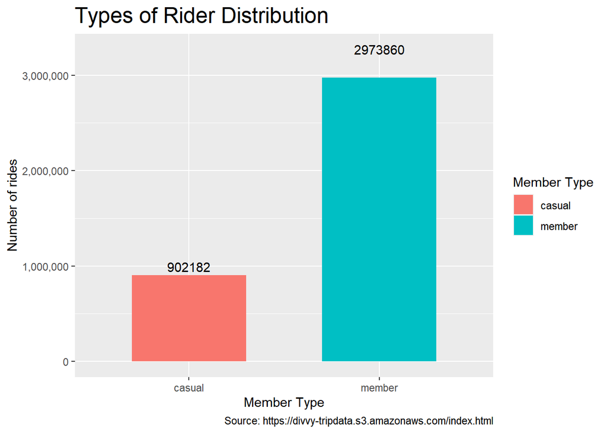

```r
all_trips_v2|>
  group_by(member_casual) |>
  summarise(member_type_n = n()) |>
  ggplot(aes(x = member_casual, y = member_type_n,
             fill = member_casual)) +
  geom_col(width = 0.6) +
  scale_y_continuous(labels = comma) + # fix the y-axis scale 3e+06 bla bla
  labs(
    title = "Types of Rider Distribution",
    x = "Member Type",
    y = "Number of rides",
    caption = "Source: https://divvy-tripdata.s3.amazonaws.com/index.html",
    fill = "Member Type"
  ) +
  geom_text(aes(label = member_type_n),
            position = position_stack(vjust = 1.1)) +
  theme(plot.title = element_text(size = 18))
```

### Number of Rides by Rider Types on Day of Week.

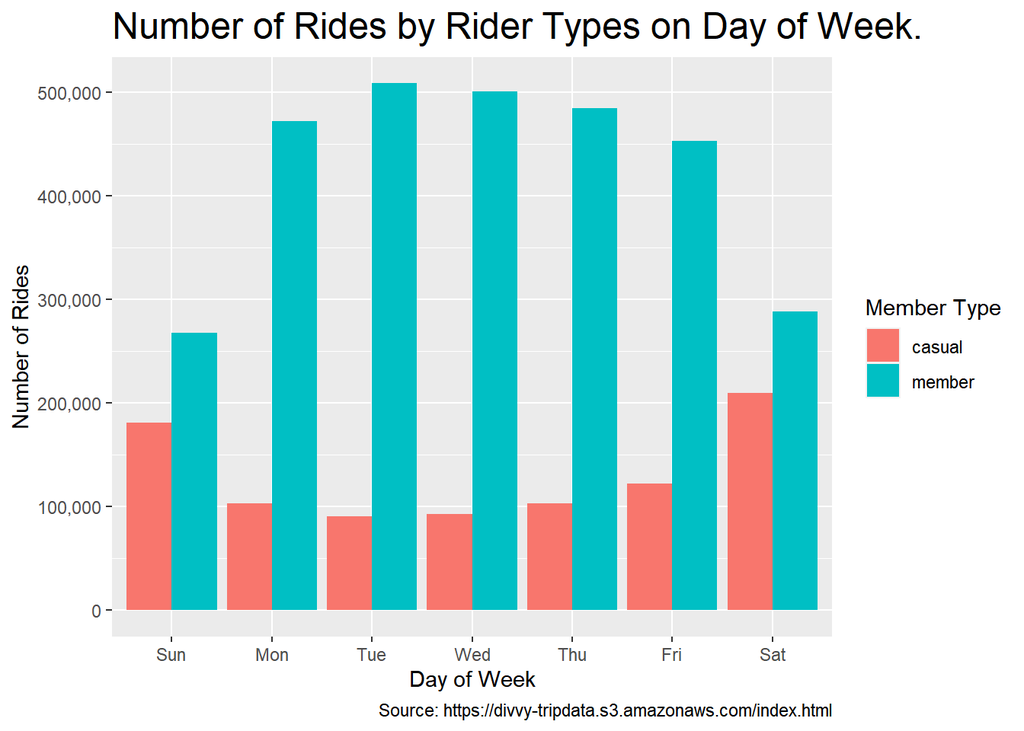

```r
all_trips_v2 %>%
  mutate(weekday = wday(started_at, label = TRUE)) %>%
  group_by(member_casual, weekday) %>%
  summarise(number_of_rides = n()
            ,average_duration = mean(ride_length)) %>%
  arrange(member_casual, weekday)  %>%
  ggplot(aes(x = weekday, y = number_of_rides, fill = member_casual)) +
  geom_col(position = "dodge") +
  scale_y_continuous(labels = comma) +
    labs(
    title = "Number of Rides by Rider Types on Day of Week.",
    x = "Day of Week",
    y = "Number of Rides",
    caption = "Source: https://divvy-tripdata.s3.amazonaws.com/index.html",
    fill = "Member Type"
  ) +
  theme(plot.title = element_text(size = 18))
```

### Average Duration between Member Types and Day off Week

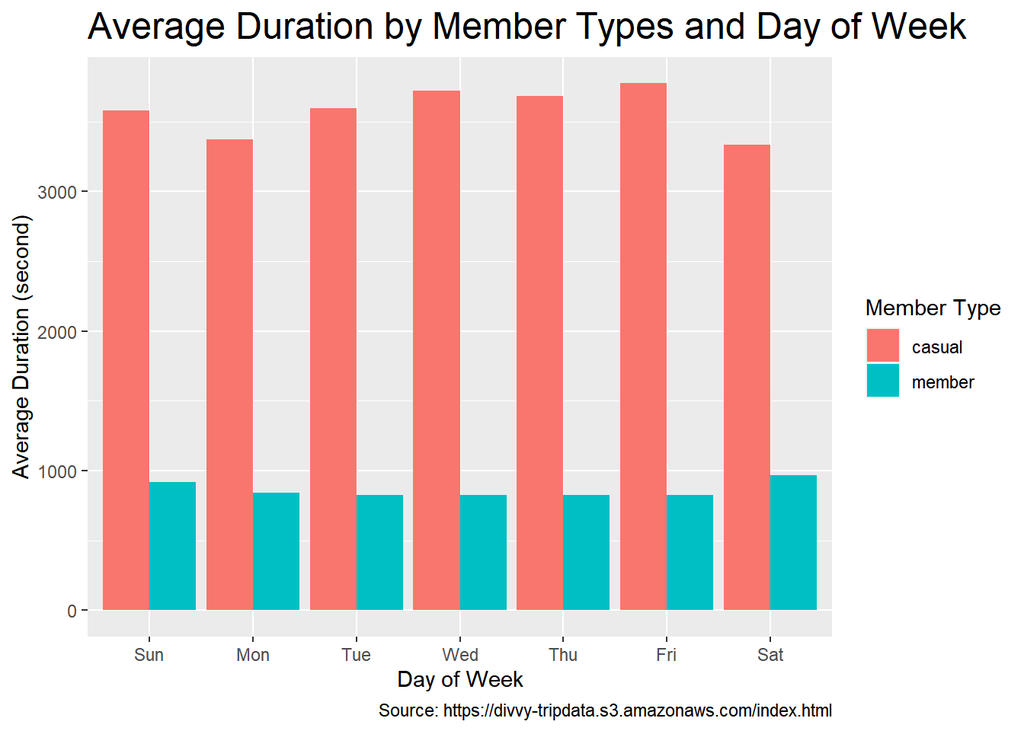

```r
all_trips_v2 %>%
  mutate(weekday = wday(started_at, label = TRUE)) %>%
  group_by(member_casual, weekday) %>%
  summarise(number_of_rides = n()
            ,average_duration = mean(ride_length)) %>%
  arrange(member_casual, weekday)  %>%
  ggplot(aes(x = weekday, y = average_duration, fill = member_casual)) +
  geom_col(position = "dodge") +
  labs(
    title = "Average Duration by Member Types and Day of Week",
    x = "Day of Week",
    y = "Average Duration (second)",
    caption = "Source: https://divvy-tripdata.s3.amazonaws.com/index.html",
    fill = "Member Type"
  )+
  theme(plot.title = element_text(size = 18))
```

### Top 10 station with highest number of rides stack by member types

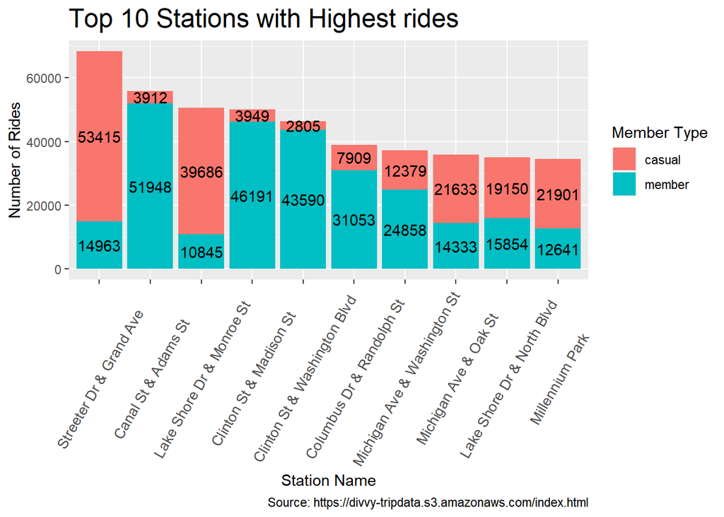

```r
all_trips_v2 |>
  group_by(start_station_name) |>
  summarise(total_ride = n()) |>
  inner_join(
    all_trips_v2 |>
      group_by(start_station_name, member_casual) |>
      summarise(number_of_rides = n()) |>
      arrange(start_station_name, desc(number_of_rides)), by = "start_station_name") |>
  arrange(desc(total_ride), start_station_name) |>
  slice(1:20) |>
  ggplot(aes(x = reorder(start_station_name, -number_of_rides), y = number_of_rides,
             fill = member_casual)) +
  geom_col() +
  labs(
    title = "Top 10 Stations with Highest rides",
    x = "Station Name",
    y = "Number of Rides",
    caption = "Source: https://divvy-tripdata.s3.amazonaws.com/index.html",
    fill = "Member Type"
  ) +
  geom_text(aes(label = number_of_rides),
            position = position_stack(vjust = 0.5)) +
  theme(axis.text.x = element_text(angle = 60, vjust = 0.5, size = 10),
        plot.title = element_text(size = 18))
```

### The Distribution of Rides by Quarter and Member Type.

[output not shown]

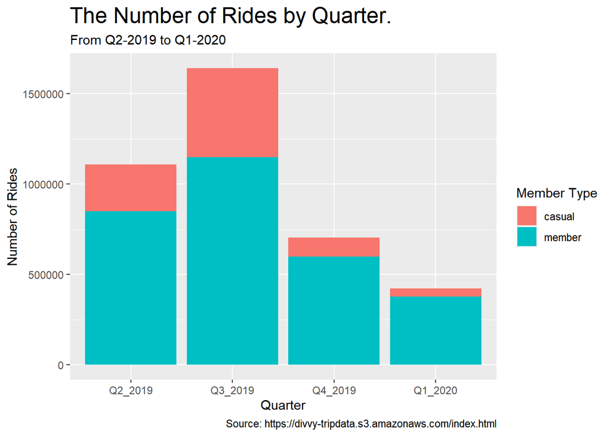

```r
all_trips_v2 |>
  group_by(Q, member_casual) |>
  summarise(number_of_rides = n())|>
  arrange(Q) |>
  mutate(Q = factor(
    Q,
    levels = c("Q2_2019", "Q3_2019", "Q4_2019", "Q1_2020"),
    ordered = TRUE)) |>
  ggplot(aes(x = Q, y = number_of_rides, fill = member_casual)) +
  geom_col() +
  labs(
    title = "The Number of Rides by Quarter.",
    subtitle = "From Q2-2019 to Q1-2020",
    x = "Quarter",
    y = "Number of Rides",
    caption = "Source: https://divvy-tripdata.s3.amazonaws.com/index.html",
    fill = "Member Type"
  ) +
  theme(plot.title = element_text(size = 18))
```

## **My Recommendations**

### 1. We should launch our marketing campaigns in the 2nd-Quarter to 3rd-Quarter for more reach our customers.

### 2. We can start a marketing pre-launch at

- **Streeter Dr & Grand Avw**,
- **Lake Shore Dr & Monroe St**,
- **Michigan Ave & Oak St** , **Lake Shore Dr & North Blvd** ,
- **Lake Shore Dr & North Blvd**

### 3. The messages on canpaign should focus on the average duration of casual rider.